# DSCI 101 HW #2

Charles Etuk

2023-02-10

### Question 1

##### 1a) Create a data frame that is a subset of the Teams data frame that contains only the years from 2000 through 2009 and the variables yearID, W, and L.

*Code:*

```r
SelectYears <- filter(Teams, yearID >= 2000 & yearID <= 2009) %>% select(yearID, W, L)
SelectYears
```

```
##     yearID   W   L
## 1     2000  82  80
## 2     2000  85  77
## 3     2000  95  67
## 4     2000  74  88
## 5     2000  85  77
## 6     2000  95  67
## 7     2000  65  97
## 8     2000  85  77
## 9     2000  90  72
## 10    2000  82  80
## 11    2000  79  83
## 12    2000  79  82
## 13    2000  72  90
## 14    2000  77  85
```

[output cut: 286 more lines]

##### 1b) How many years did the Chicago Cubs (teamID is “CHN”) hit at least 200 HRs in a season and what was the median number of wins in those seasons.

*Code:*

```r
ChicagoTeams <- Teams %>% filter(Teams$teamID == "CHN") %>% filter(HR >= 200)
ChicagoTeams %>% nrow()
```

```
## [1] 7
```

```r
summary(ChicagoTeams$W)
```

```
##    Min. 1st Qu.  Median    Mean 3rd Qu.    Max.
##   67.00   73.50   84.00   81.29   89.50   92.00
```

There were 7 years where the Chicago Cubs hit at least 200 home runs, and the median number of wins in those seasons was 84.

##### 1c) Make a line plot of total home runs per season and stratify by league. (Remove observations where league is missing.) Comment on anything interesting that you observe.

*Code:*

```r
OneC <- Teams %>% group_by(yearID, lgID) %>% summarize(HRbyLg = sum(HR))
```

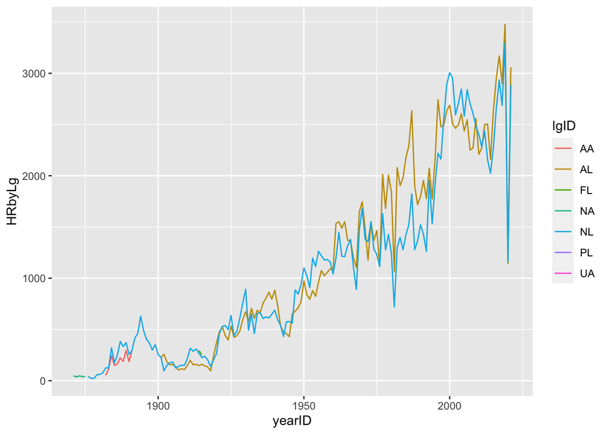

```r
ggplot(aes(x = yearID, y = HRbyLg), data = OneC) + geom_line(aes(color = lgID))
```

The line plot has dips around 1981 and 2020, which can be explained by the MLB strike in 1981, and Covid-19 respectively. Also, while the NL and AL graphs relatively follow the same pattern, it’s interesting that from 1975 to around 1990 there seems to be a major disparity in home run totals.

##### 1d) Create an indicator variable called “winning record” which is defined as TRUE if the number of wins is greater than the number of losses and FALSE otherwise. Plot a scatter plot of Runs (R) vs Runs against (RA) with the color of each point showing whether that team had a winning record or not.

*Code:*

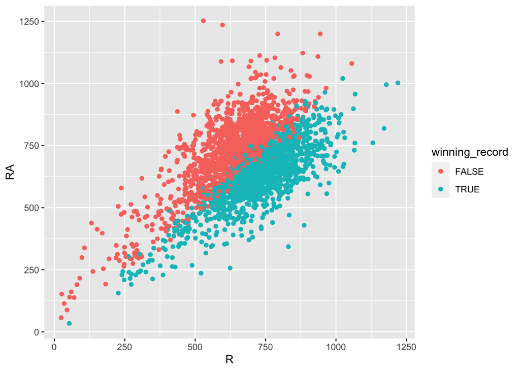

```r
Teams <- mutate(Teams, winning_record = Teams$W > Teams$L)
ggplot(aes(x = R, y = RA), data = Teams) + geom_point(aes(color = winning_record))
```

##### 1e) Using ggplot2, create a scatterplot of strikeouts (SO) vs walks (BB).

*Code:*

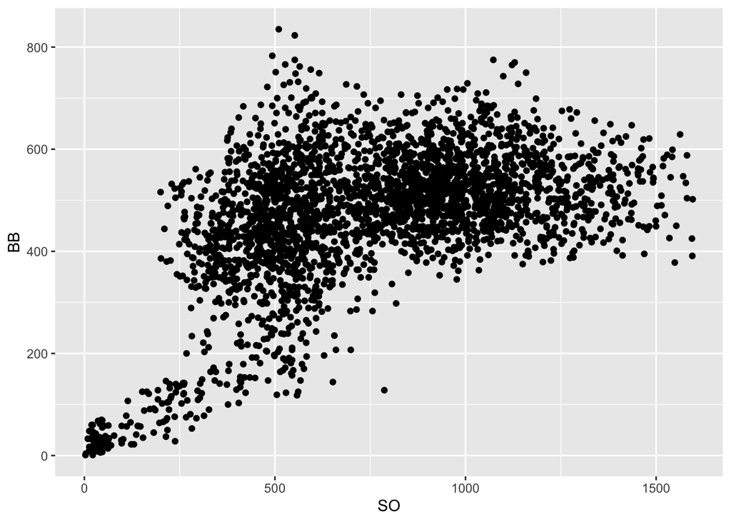

```r
ggplot(aes(x = SO, y = BB), data = Teams) + geom_point()
```

##### 1f) Create a categorical variable with 4 levels: before 1900, 1900 - 1949, 1950-1999, 2000 or later. (Hint: There is a function called ’cut’ that will help you here.) Use this as the color of the point in the scatterplot of strikeouts vs walks that you created in the previous problem.

*Code:*

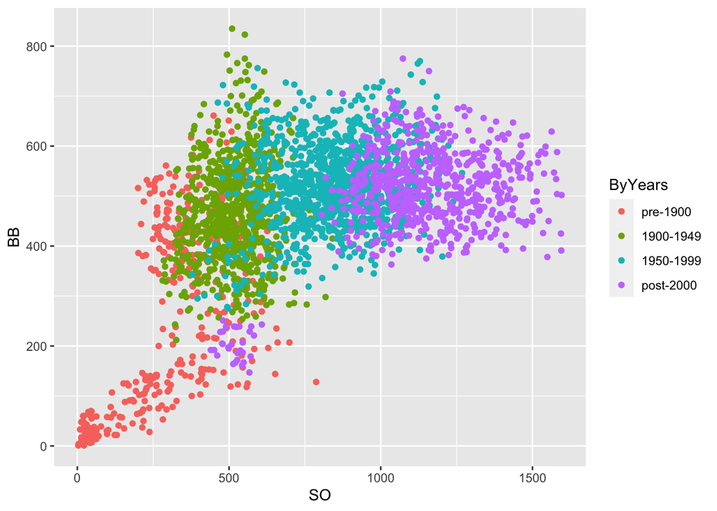

```r
Teams <- Teams %>% mutate(ByYears = cut(yearID, breaks = c(0, 1900, 1949, 1999, 2023), labels = c("pre-1900", "1900-1949", "1950-1999", "post-2000")))
ggplot(aes(x = SO, y = BB), data = Teams) + geom_point(aes(color = ByYears))
```

### Question 2

##### 2a) What month had the highest proportion of cancelled flights? What month had the lowest? Interpret any seasonal patterns.

*Code:*

```r
Flights <- flights
Flights %>% mutate(Cancelled = is.na(dep_time)) %>% group_by(month) %>% summarize(PropCancelled = mean(Cancelled)) %>% arrange(-PropCancelled)
```

```
## # A tibble: 12 × 2
##    month PropCancelled
##    <int>         <dbl>
##  1     2       0.0505
##  2    12       0.0364
##  3     6       0.0357
##  4     7       0.0319
##  5     3       0.0299
##  6     4       0.0236
##  7     5       0.0196
##  8     1       0.0193
##  9     8       0.0166
## 10     9       0.0164
## 11    11       0.00854
## 12    10       0.00817
```

February had the highest proportion of cancelled flights while October had the lowest proportion. As for seasonal trends, the top two months are during the winter season, while the bottom 3 are all fall months.

##### 2b) Create a histogram of the departure delays times (dep delay) for all flights that had a delay time greater than 0.

*Code:*

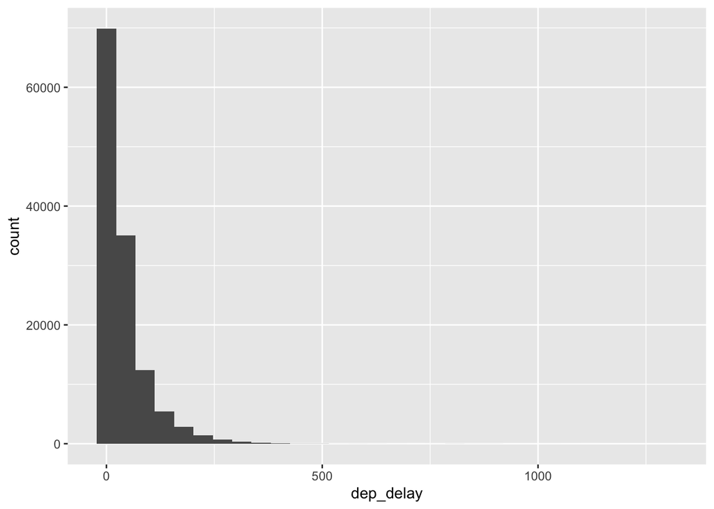

```r
DelayedFlights <- filter(Flights, dep_delay > 0)
ggplot(aes(x = dep_delay), data = DelayedFlights) + geom_histogram()
```

##### 2c) Repeat the same histogram, but now facet by month.

*Code:*

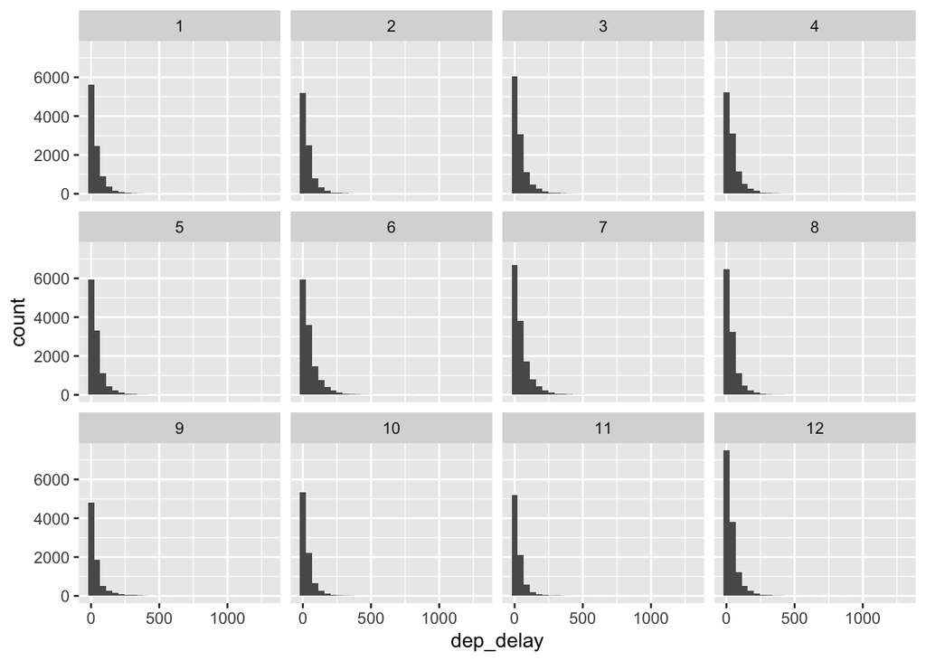

```r
DelayedFlights <- filter(Flights, dep_delay > 0)
ggplot(aes(x = dep_delay), data = DelayedFlights) + geom_histogram() + facet_wrap(~month)
```

##### 2d) Create side-by-side boxplots of delay times for flights with delays 60 minutes or greater for the top 5 airlines (in terms of number of flights).

*Code:*

```r
Flights %>% filter(dep_delay >= 60) %>% group_by(carrier) %>% summarize(TotalFlights = table(carrier)) %>% arrange(-TotalFlights) %>% head(5)
```

```
## # A tibble: 5 × 2
##   carrier TotalFlights
##   <chr>   <table[1d]>
## 1 EV      6984
## 2 B6      4655
## 3 UA      3899
## 4 DL      2699
## 5 MQ      2037
```

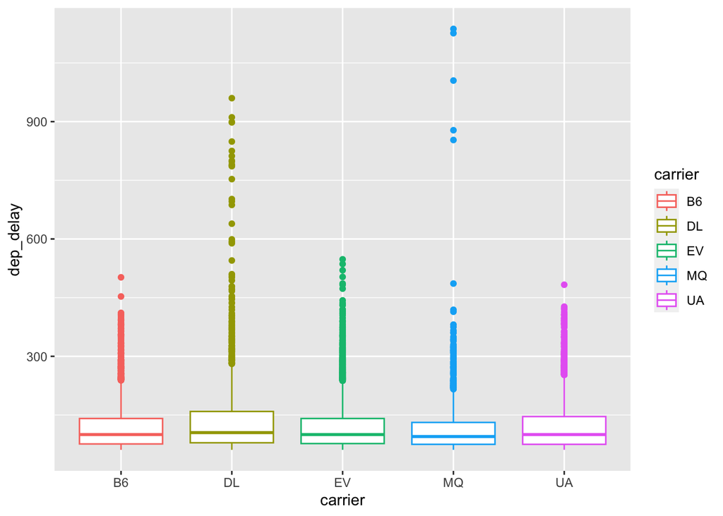

```r
TopCarriersBoxPlot <- Flights %>% filter(dep_delay > 60, carrier == "EV" | carrier == "B6" | carrier == "UA" | carrier == "DL" | carrier == "MQ")
ggplot(aes(y = dep_delay, x = carrier), data = TopCarriersBoxPlot) + geom_boxplot(aes(color = carrier))
```